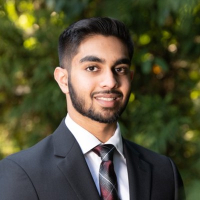

# Sahil S. Patel

## Bio

Thanks for wanting to get to know me a bit better! I am a student at the University of Toronto (St. George campus) hopefully going to be studying the theory of statistics and computer science. I would love to work in academia or financial technology when I’m older, however the world of statistics is so incredibly diverse that I’m not sure exactly what I want to do! A quick synopsis of my work life is below, but check out my CV, blog posts, and more on my main website!

## Education

**University of Toronto, St. George** | Toronto, Ontario

(Hopefully) Specializing in the Theory and Methods of Statistics | September 2020 - Present

(Hopefully) Minoring in Computer Science | September 2020 - Present

## Experience

**PredictNow.ai** | Consultant/Intern | April 2021 - Present

**Goldfinch STA** | Intern | November 2017 - August 2019 & May 2021 - Present

**Vision Martial Arts** | Assistant Instructor | November 2017 - October 2020

## Personal Projects

**00100100** | Developer/Programmer | May 2021 - Present

**R6S Talent League** | North American Director | October 2019 - January 2021

**R6S Premier Play** | Founder | June 2016 - December 2019